# **Unsupervised Learning Project: AllLife Bank Customer Segmentation**

### Overall Insight:

- **Cluster 2**: These are high-value, high-engagement customers with multiple credit cards and high credit limits. They are active both online and through in-person visits.
- **Cluster 1**: These customers have lower credit limits, fewer cards, and engage more via phone, with less frequent in-person visits.
- **Cluster 0**: This group falls between the other two clusters, with moderate credit card usage and a more balanced approach to bank interactions.

#### **Compare the clusters from K-Means and K-Medoids**

**Comparing Clusters:**___****

```python
# Create a crosstab to compare how clusters from K-Means and GMM match
comparison = pd.crosstab(data_scaled_copy['KMeans_Labels'], data_scaled_copy['KMedoids_Labels'])
print(comparison)
```

```
KMedoids_Labels    0    1    2
KMeans_Labels
0                211    0    0
1                  0  221    0
2                  0    3   46
3                  0    0  174
```

The cross-tabulation between **K-Means** and **K-Medoids** labels provides insight into how clusters from both algorithms align or differ. Here's how to interpret the table:

### Interpretation:

1. **Cluster 0 (K-Means) vs. K-Medoids:**
   - All **211 data points** that were assigned to cluster 0 in **K-Means** were also assigned to cluster 0 in **K-Medoids**.
   - This shows perfect alignment for cluster 0 between the two algorithms.
2. **Cluster 1 (K-Means) vs. K-Medoids:**
   - All **221 data points** in **K-Means cluster 1** were assigned to **K-Medoids cluster 1**.
   - There is a one-to-one correspondence here, meaning both algorithms are in agreement about the data points in cluster 1.
3. **Cluster 2 (K-Means) vs. K-Medoids:**
   - Out of **49 data points** assigned to **K-Means cluster 2**, **46 data points** were assigned to **K-Medoids cluster 2**, but **3 data points** were assigned to **K-Medoids cluster 1**.
   - This indicates that while most data points agree between the algorithms, **K-Medoids** shifted a few data points (3) from **K-Means cluster 2** to **K-Medoids cluster 1**.
4. **Cluster 3 (K-Means) vs. K-Medoids:**
   - All **174 data points** assigned to **K-Means cluster 3** were also assigned to **K-Medoids cluster 2**.
   - This shows a strong alignment between these clusters, though there is a numbering mismatch where K-Means labels it as cluster 3, and K-Medoids calls it cluster 2.

### Conclusion:

The comparison shows that **K-Means** and **K-Medoids** largely agree on the cluster assignments, especially for clusters 0 and 1. However, there is some minor discrepancy between cluster 2 and cluster 3, where a small number of data points were assigned differently between the two methods.

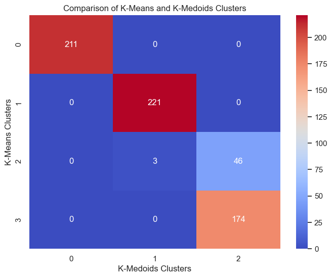

```python
# We can also visualize the comparison using a heatmap

plt.figure(figsize=(8, 6))
sns.heatmap(comparison, annot=True,cmap='coolwarm', fmt='d')
plt.title("Comparison of K-Means and K-Medoids Clusters")
plt.xlabel("K-Medoids Clusters")
plt.ylabel("K-Means Clusters")
plt.show()
```

**Insights:**

Overall, the heatmap shows that K-Means and K-Medoids clusters mostly align, with some minor discrepancies in Cluster 2. The differences may result from how K-Medoids assigns cluster centers (medoids) compared to K-Means, which can cause small shifts in clustering outcomes.

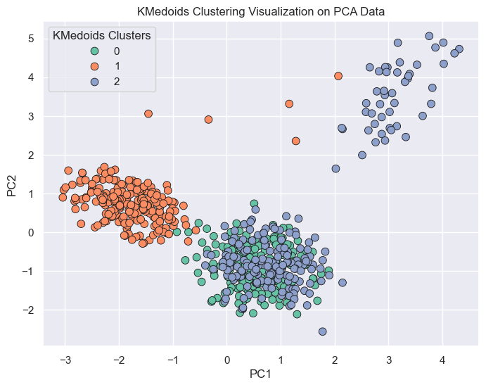

```python
#Visualizing KMedoids Clusters:

plt.figure(figsize=(8,6))
sns.scatterplot(x=data_scaled_copy['PC1'], y=data_scaled_copy['PC2'], hue=data_scaled_copy['KMedoids_Labels'], palette='Set2', s=60, edgecolor='k')
plt.title("KMedoids Clustering Visualization on PCA Data")
plt.xlabel("PC1")
plt.ylabel("PC2")
plt.legend(title="KMedoids Clusters")
plt.show()
```